# Text Cleanup and Sentiment Analysis

Media Data Science

10/23/2019

##Data Collection

For now, we manually extracted the comments to each twitter post. This data collection method is okay for this smaller ad hoc request, but long term, we want to use the twitter API to collect tweets and all the attributes belonging to tweets.

```r
library(readxl)
twitter_comments <- read_excel("C:/Users/traveler/Desktop/Results/senitment/twitter_comments.xlsx")
twitter_comments$ID <- seq.int(nrow(twitter_comments))
head(twitter_comments)
```

```
## # A tibble: 6 x 5
##   type   wave  post_url                 comment                          ID
##   <chr>  <chr> <chr>                    <chr>                         <int>
## 1 twitt~ one   https://twitter.com/bus~ Did renewal energy power the~     1
## 2 twitt~ one   https://twitter.com/bus~ To maintain them you will st~     2
## 3 twitt~ one   https://twitter.com/bus~ No way                            3
## 4 twitt~ one   https://twitter.com/bus~ RE needs FF but not vice ver~     4
## 5 twitt~ one   https://twitter.com/bus~ Er yes, why is it worth the ~     5
## 6 twitt~ one   https://twitter.com/bus~ Is co2 the trigger for clima~     6
```

##Text Processing

Bring in text processing packages

```r
#install.packages(c('tm', 'SnowballC', 'wordcloud', 'topicmodels'))
library(tm)
library(SnowballC)
library(wordcloud)
library(topicmodels)
```

Proccess text

```r
#convert the comments into a corpus
corpus = Corpus(VectorSource(twitter_comments$comment))

#make all characters lowercase
corpus = tm_map(corpus, content_transformer(tolower))

#remove numbers
corpus = tm_map(corpus, removeNumbers)

#remove punctuation
corpus = tm_map(corpus, removePunctuation)

#remove commo english stop words
corpus = tm_map(corpus, removeWords, c("the", "and", stopwords("english")))

#strip whitespace
corpus =  tm_map(corpus, stripWhitespace)

#inspect first element
inspect(corpus[1])
```

```
## <<SimpleCorpus>>
## Metadata:  corpus specific: 1, document level (indexed): 0
## Content:  documents: 1
##
## [1]  renewal energy power ships supply ships provide transport get wind turbines docks lets guess answer
```

```r
#convert corpus with clean text back to data frame and export into spreadsheet
clean_twitter<-data.frame(text = sapply(corpus, as.character), stringsAsFactors = FALSE)
clean_twitter$ID <- seq.int(nrow(clean_twitter))

#join clean comments with urls on unique id created
library(sqldf)

clean_twitter_export<-sqldf("
                            select
                            a.ID ,
                            a.text,
                            b.type,
                            b.wave,
                            b.post_url
                            from clean_twitter a
                            join twitter_comments b
                            on (a.ID=b.ID)
                            ")

head(clean_twitter_export)
```

```
##   ID
## 1  1
## 2  2
## 3  3
## 4  4
## 5  5
## 6  6
##                                                                                                                                                                      text
## 1                                                                    renewal energy power ships supply ships provide transport get wind turbines docks lets guess answer
## 2  maintain will still use fossil fuels ships company probably arent local people flights cars involved life span turbines happens just leave will need removed disposed
## 3                                                                                                                                                                     way
## 4                                                                                                                                          re needs ff vice versa contest
## 5                                                                                                                   er yes worth debate oh yeah america puts profit lives
## 6                                                                                                                   co trigger climate change just money making scapegoat
##      type wave                                                post_url
## 1 twitter  one https://twitter.com/business/status/1153400137294798849
## 2 twitter  one https://twitter.com/business/status/1153400137294798849
## 3 twitter  one https://twitter.com/business/status/1153400137294798849
## 4 twitter  one https://twitter.com/business/status/1153400137294798849
## 5 twitter  one https://twitter.com/business/status/1153400137294798849
## 6 twitter  one https://twitter.com/business/status/1153400137294798849
```

```r
write.table(clean_twitter_export, "c:/clean_twitter.txt", sep="\t")
```

##EDA on Text

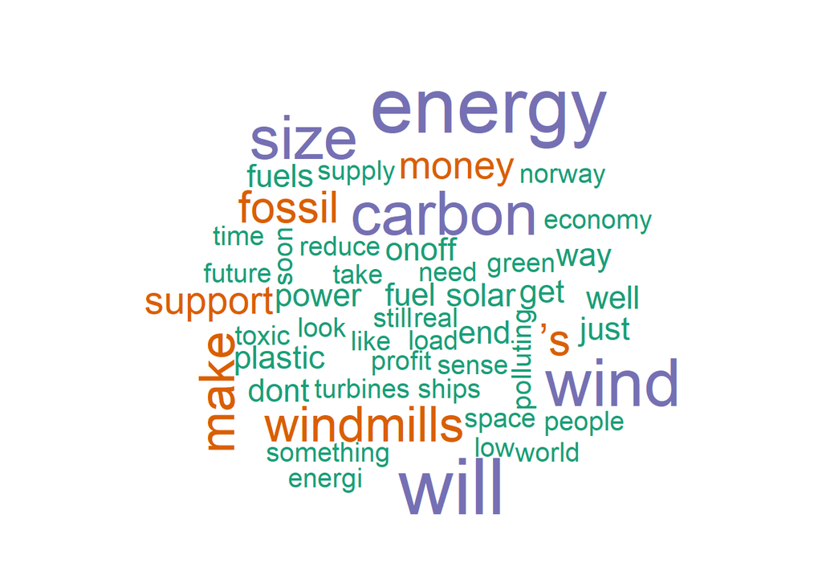

```r
#convert to document term matrix and remove sparse terms
review_dtm <- DocumentTermMatrix(corpus)
review_dtm = removeSparseTerms(review_dtm, 0.99)

#generate simple word cloud on the twitter comments
freq = data.frame(sort(colSums(as.matrix(review_dtm)), decreasing=TRUE))
wordcloud(rownames(freq), freq[,1], max.words=50, colors=brewer.pal(1, "Dark2"))
```

[figure not shown]

```r
#appy TF-IDF
review_dtm_tfidf <- DocumentTermMatrix(corpus, control = list(weighting = weightTfIdf))
review_dtm_tfidf = removeSparseTerms(review_dtm_tfidf, 0.95)

#generate word cloud based on Tf-IDF
freq = data.frame(sort(colSums(as.matrix(review_dtm_tfidf)), decreasing=TRUE))
wordcloud(rownames(freq), freq[,1], max.words=100, colors=brewer.pal(1, "Dark2"))
```

##Sentiment Analysis

We will be using the syuzhet package to perform our analysis. The biggest advatage of this package is that it is built on top of a robust ground truth. An experiment was performed asking people to tag words with one of 8 emotions and overall sentiment such as positive or negative. In other words,the ground truth was collected using human intelligence. The lexicons are manually built from arbitrary texts. There were a total of 14k words classified by humans and built into the r package as ground truth. For more information, please see the following soruces:

- http://saifmohammad.com/WebPages/NRC-Emotion-Lexicon.htm
- http://sentiment.nrc.ca/lexicons-for-research/
- https://cran.r-project.org/web/packages/syuzhet/vignettes/syuzhet-vignette.html

```r
#install_github('trinker/sentimentr')

library(sentimentr)
library(tidytext)
library("syuzhet")
library("twitteR")
```

```r
tweets.df <- subset(twitter_comments, select=c(comment) )

tweets.df2 <- gsub("http.*","",tweets.df$comment)

tweets.df2 <- gsub("https.*","",tweets.df2)

tweets.df2 <- gsub("#.*","",tweets.df2)

tweets.df2 <- gsub("@.*","",tweets.df2)
```

```r
word.df <- as.vector(tweets.df2)

emotion.df <- get_nrc_sentiment(word.df)

emotion.df2 <- cbind(tweets.df2, emotion.df)

head(emotion.df2)
```

```
##                                                                                                                                                                                                                                                                           tweets.df2
## 1                                                                                                                                  Did renewal energy power the ships and supply ships . Did it provide the transport to get the wind turbines to the docks . Let's guess. Answer NO
## 2 To maintain them you will still use fossil fuels. The ships company probably aren't all local people so there would be flights of cars involved. And the life span of the turbines . What happens then do we just leave them or will they need to be removed and disposed of them.
## 3                                                                                                                                                                                                                                                                             No way
## 4                                                                                                                                                                                                                                         RE needs FF but not vice versa. No contest
## 5                                                                                                                                                                                                        Er yes, why is it worth the debate, oh yeah america puts profit above lives
## 6                                                                                                                                                                                                             Is co2 the trigger for climate change or just a money making scapegoat
##   anger anticipation disgust fear joy sadness surprise trust negative
## 1     0            0       0    0   0       0        1     1        0
## 2     0            1       0    0   0       1        1     1        1
## 3     0            0       0    0   0       0        0     0        0
## 4     0            0       0    0   0       0        0     0        1
## 5     0            0       0    0   0       0        0     0        0
## 6     2            1       0    2   1       0        1     1        1
##   positive
## 1        3
## 2        1
## 3        0
## 4        0
## 5        2
## 6        1
```

## Parse by Most Positive Comment

```r
sent.value <- get_sentiment(word.df)

most.positive <- word.df[sent.value == max(sent.value)]

most.positive
```

```
## [1] "I look forward to the young Generations paving a way to have a future, and supporting them in that goal. If that means to remove obstacles I'm glad to assist as well."
```

## Parse by most Negative Comment

```r
most.negative <- word.df[sent.value <= min(sent.value)]

most.negative
```

```
## [1] "Strangely enough, it seems historically to be countries with a large governmental apparatus where problems regarding greed and corruption have had the biggest consequences for its citizens, like famines and civil wars. But you sound like you look forward to violent revolutions."
```

## Aggregate scores and display overall sentiment by comment

```r
positive.tweets <- word.df[sent.value > 0]

negative.tweets <- word.df[sent.value < 0]

neutral.tweets <- word.df[sent.value == 0]

# Alternate way to classify as Positive, Negative or Neutral tweets

category_senti <- ifelse(sent.value < 0, "Negative", ifelse(sent.value > 0, "Positive", "Neutral"))

category_senti2 <- cbind(twitter_comments,category_senti)

#export results to txt file
write.table(category_senti2, "c:/clean_twitter_w_sentiment.txt", sep="\t")
```

## Visualize the distribution of sentiment by number of tweets

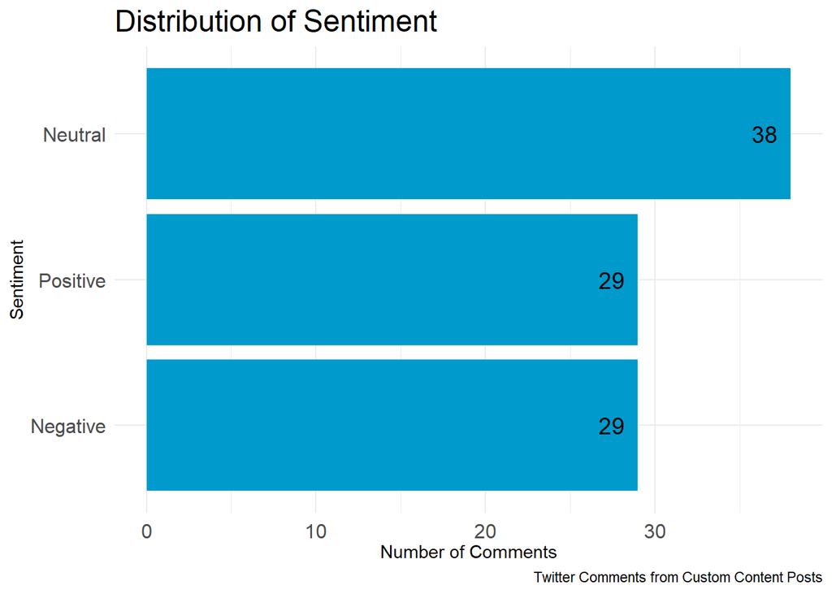

```r
library(ggplot2)

comment_viz<-sqldf("
                   select
                   category_senti, count(distinct comment) as num_comments
                   from category_senti2
                   group by category_senti
                   ")

ggplot(comment_viz, aes(x=reorder(category_senti,num_comments),round(num_comments, digits=2)))+
  geom_bar(stat="identity", fill="deepskyblue3")+
  geom_text(aes(label=round(num_comments, digits=2)), vjust=0.5, size=5, position=position_dodge(width = 1), hjust=1.5)+
  theme_minimal()+
  theme(axis.text.x=element_text(size=12, vjust=0.5))+
  theme(axis.text.y=element_text(size=12, vjust=0.5))+
  theme(plot.title = element_text(size=18))+
  labs( x="Sentiment", y="Number of Comments")+
  coord_flip()+
  labs(caption="Twitter Comments from Custom Content Posts")+
  ggtitle("Distribution of Sentiment")
```